# Commonality analysis for mental health and stacked set of brain features models

Yue Wang and Narun P

09 Sep, 2023

```
##          used (Mb) gc trigger (Mb) limit (Mb) max used (Mb)
## Ncells 532510 28.5    1186751 63.4         NA   669411 35.8
## Vcells 987962  7.6    8388608 64.0     131072  1851587 14.2
```

## 0.1 Note

Here we the ABCD release 4.0 data-set

# 1 Setting up the environment

## 1.1 Loading libraries

The following libraries and default settings were used during the analysis:

```r
options(scipen = 999)
#library("sva")
library(tidyverse)
library("tidymodels")
```

```r
##parallel map
library(partR2)
library(lme4)
library(yhat)
library(ggtext)
library(ggpubr)
library(cowplot)
library(partR2)
library(lme4)
library(yhat)
library("VennDiagram")
## library to tidy up the linear mixed models
library(sjPlot)
theme_set(theme_bw() + theme(panel.grid = element_blank()))
## parallel processing number of cores register
all_cores <- parallel::detectCores(logical = FALSE) - 5

doParallel::registerDoParallel(cores = all_cores)
```

## 1.2 Setting up the library path

We first loaded all of the relevant data files (not shown here as they refer to local directories):

## 1.3 load fitted gfactors from brain scan and psychopathology

### 1.3.1 load brain scan fitted results from stacking models

```r
rf_baseline <- readRDS(paste0(scriptfold,"stacking_gfactor_modelling/collect_random_forest_results/random_forest_baseline_results.RDS"))

rf_followup <- readRDS(paste0(scriptfold,"stacking_gfactor_modelling/collect_random_forest_results/random_forest_followup_results.RDS"))
```

### 1.3.2 load the mental health predicted results

```r
psy_pred <- readRDS(paste0(scriptfold,"Common_psy_gene_brain_all/saved_outputs/psychopathology_pls_pred_2.0.RData"))
```

### 1.3.3 load the computed gfactor

```r
gfactor_list <- readRDS(paste0(scriptfold,"genetics_psychopathology_common_scan_all_scripts/gfactor_scale_seperate.RData"))
```

Be careful with what site you choose.

```r
rf_baseline_pred <- map(rf_baseline,"test_pred")
rf_baseline_pred_tibble <- map(rf_baseline_pred,"model_predict")
rf_baseline_table <- map(rf_baseline,"test_data")

rf_followup_pred <- map(rf_followup,"test_pred")
rf_followup_pred_tibble <- map(rf_followup_pred,"model_predict")
rf_followup_table <- map(rf_followup,"test_data")
```

```r
gfactor_baselie_test <- map(gfactor_list,"output_test_baseline")
gfactor_followup_test <- map(gfactor_list,"output_test_followup")
```

```r
subj_info <- c("SUBJECTKEY","SITE_ID_L","EVENTNAME")
```

load in family index data

```r
ACS <-read_csv(paste0(datafolder,"ACSPSW03_DATA_TABLE.csv"))
#knitr::kable(glimpse(ACS))

#race_ethnicity
#1 = White; 2 = Black; 3 = Hispanic; 4 = Asian; 5 = Other

# guardian-report relationship
# Relationship of the participant in his or her family
# 0 = single; 1 = sibling; 2 = twin; 3 = triplet
# ACS %>% count(REL_RELATIONSHIP)

ACSselected <- ACS %>%
  select(SUBJECTKEY, EVENTNAME, SEX, INTERVIEW_AGE, RACE_ETHNICITY,
                              REL_FAMILY_ID, ACS_RAKED_PROPENSITY_SCORE) %>%
  mutate(RACE_ETHNICITY = recode_factor(as.factor(RACE_ETHNICITY),
                `1` = "White", `2` = "Black", `3` = "Hispanic", `4` = "Asian", `5` = "Other",
                .default = "White")) %>%
  mutate(SEX = as.factor(SEX)) %>%
  mutate(REL_FAMILY_ID = as.factor(REL_FAMILY_ID))

ACSselected %>%
 filter(EVENTNAME =="baseline_year_1_arm_1") %>%
 skimr::skim()
```

Data summary

| Name | Piped data |
| --- | --- |
| Number of rows | 11876 |
| Number of columns | 7 |
| _______________________ |  |
| Column type frequency: |  |
| character | 2 |
| factor | 3 |
| numeric | 2 |
| ________________________ |  |
| Group variables | None |

**Variable type: character**

| skim_variable | n_missing | complete_rate | min | max | empty | n_unique | whitespace |
| --- | --- | --- | --- | --- | --- | --- | --- |
| SUBJECTKEY | 0 | 1 | 12 | 16 | 0 | 11876 | 0 |
| EVENTNAME | 0 | 1 | 21 | 21 | 0 | 1 | 0 |

**Variable type: factor**

| skim_variable | n_missing | complete_rate | ordered | n_unique | top_counts |
| --- | --- | --- | --- | --- | --- |
| SEX | 0 | 1 | FALSE | 2 | M: 6196, F: 5680 |
| RACE_ETHNICITY | 2 | 1 | FALSE | 5 | Whi: 6180, His: 2411, Bla: 1784, Oth: 1247 |
| REL_FAMILY_ID | 0 | 1 | FALSE | 9854 | 373: 5, 749: 4, 11: 3, 400: 3 |

**Variable type: numeric**

| skim_variable | n_missing | complete_rate | mean | sd | p0 | p25 | p50 | p75 | p100 | hist |
| --- | --- | --- | --- | --- | --- | --- | --- | --- | --- | --- |
| INTERVIEW_AGE | 0 | 1 | 118.98 | 7.50 | 107.00 | 112.00 | 119.00 | 126.00 | 133.00 | ▇▆▆▆▆ |
| ACS_RAKED_PROPENSITY_SCORE | 0 | 1 | 691.34 | 350.98 | 161.36 | 449.35 | 619.31 | 821.74 | 1778.92 | ▅▇▂▂▁ |

```r
ACSselected_baseline <- ACSselected %>%
                        filter(EVENTNAME =="baseline_year_1_arm_1")%>%
                        select(SUBJECTKEY,REL_FAMILY_ID)

ACSselected_followup <- ACSselected %>%
                        filter(EVENTNAME =="1_year_follow_up_y_arm_1")%>%
                        select(SUBJECTKEY,REL_FAMILY_ID)
```

```r
pred_processing <- function(baseline_pred, followup_pred, baseline_table, followup_table,pred_name){
  names_vec <- c(subj_info,pred_name)

  baseline_subj_info <- baseline_table %>% select(all_of(subj_info))
  baseline_pred_vec <- baseline_pred %>% select(model_predict)
  baseline_output <- bind_cols(baseline_subj_info,baseline_pred_vec)
  names(baseline_output) <- names_vec

  followup_subj_info <- followup_table %>% select(all_of(subj_info))
  followup_pred_vec <- followup_pred %>% select(model_predict)
  followup_output <- bind_cols(followup_subj_info,followup_pred_vec)
  names(followup_output) <- names_vec

  output_all <- bind_rows(baseline_output,followup_output)
  return(list(baseline_output = baseline_output,
              followup_output = followup_output))
}
```

```r
processed_rf_results <- pmap(list(rf_baseline_pred_tibble,rf_baseline_table,
                                  rf_followup_pred_tibble,rf_followup_table),
                             ~pred_processing(baseline_pred=..1,
                                              followup_pred=..3,
                                              baseline_table=..2,
                                              followup_table=..4,
                                              pred_name="random_forest_stacking"))


processed_psy_results <- pmap(list(psy_pred[["baseline_test_pred"]],
                                   psy_pred[["baseline_test_data"]],
                                  psy_pred[["followup_test_pred"]],
                                  psy_pred[["followup_test_data"]]),
                             ~pred_processing(baseline_pred=..1,
                                              followup_pred=..3,
                                              baseline_table=..2,
                                              followup_table=..4,
                                              pred_name="psychopathology_pls"))
```

```r
site_char <- names(processed_psy_results)
```

## 1.4 Join all the data

```r
join_data_all <- function(site_input){
  ### join the data and drop NA
  rf_baseline_tibble <- processed_rf_results[[site_input]][["baseline_output"]]
  rf_followup_tibble <- processed_rf_results[[site_input]][["followup_output"]]
  psy_baseline_tibble <- processed_psy_results[[site_input]][["baseline_output"]]
  psy_followup_tibble <- processed_psy_results[[site_input]][["followup_output"]]


  baseline_rf_psy <- full_join(rf_baseline_tibble,
                                      psy_baseline_tibble,
                                 by =subj_info)
  followup_rf_psy <- full_join(rf_followup_tibble,
                                      psy_followup_tibble,
                                 by =subj_info)

  gfactor_baseline <- gfactor_baselie_test[[site_input]]
  gfactor_followup <- gfactor_followup_test[[site_input]]


baseline_all <- plyr::join_all(list(baseline_rf_psy,
                                      ACSselected_baseline,gfactor_baseline),
                                 by ="SUBJECTKEY", type = 'full')%>%
                                 drop_na()
  followup_all <- plyr::join_all(list(followup_rf_psy,
                                      ACSselected_baseline,gfactor_followup),
                                 by ="SUBJECTKEY", type = 'full')%>%
                                 drop_na()
 output_all <- bind_rows(baseline_all,followup_all)

  return(list(baseline = baseline_all,
              followup=followup_all,
              all = output_all))

}
```

```r
gfactor_all <- map(.x = site_char,~join_data_all(site_input = .x))

names(gfactor_all) <- site_char

gfactor_all_baseline <- map(gfactor_all,"baseline")
gfactor_all_followup <- map(gfactor_all,"followup")
gfactor_all_baseline_followup <- map(gfactor_all,"all")
```

Some explaination of the variables:

brain_savg: the average of brain prediction results within each site.

brain_cws: brain predictions centered within each site.

mental_savg: the average of mental health predictions results within each site.

mental_cws: mental health predictions centered within each site.

```r
center_by_site <- function(data_input){
  output_data <- data_input %>%
    mutate(brain_savg = mean(random_forest_stacking))%>%
    mutate(brain_cws = random_forest_stacking-brain_savg)%>%
   mutate(mental_savg = mean(psychopathology_pls))%>%
    mutate(mental_cws = psychopathology_pls - mental_savg)

return(output_data)
  }


centered_all_baseline <- map(gfactor_all_baseline,~center_by_site(data_input = .))
centered_all_followup <- map(gfactor_all_followup,~center_by_site(data_input = .))
```

## 1.6 Scale the overall data by each variable

```r
gfactor_all_pred_centered_site_baseline <- centered_all_baseline%>%
                                           do.call(rbind,.)
gfactor_all_pred_centered_site_followup <- centered_all_followup%>%
                                           do.call(rbind,.)


features_not_scale <- c(subj_info, "REL_FAMILY_ID","gfactor")

features_scale <- gfactor_all_pred_centered_site_baseline %>% select(-all_of(features_not_scale))%>% colnames()
## recipe to scale the features
recipe_scale <- function(train_input=gfactor_all_pred_centered_site_baseline){
  norm_recipe <- recipe( as.formula("gfactor~."), data = train_input) %>%
    update_role(all_of(features_scale), new_role = "predictor")%>%
    update_role("gfactor", new_role = "outcome" )%>%
    # normalize numeric predictors and outcome
    step_normalize(all_numeric_predictors())
  return(norm_recipe)
}


all_baseline_recipe <-

data_all_baseline <-recipe_scale(train_input=gfactor_all_pred_centered_site_baseline) %>%
                    prep() %>%
                    juice()


data_all_followup <-recipe_scale(train_input=gfactor_all_pred_centered_site_followup) %>%
                    prep() %>%
                    juice()
```

# 2 Commonality analysis for the models with stacked brain and mental health

We use linear mixed models in the following analyses. There is a following nested structure: participants are nested within family and family are nested within sites. The random intercepts of site seems do not have any effects on the model and it may cause singularity problems. So it is removed from the analysis.

```r
common_analysis_psy_brain <- function(data_input=data_all_baseline){

    print("brain_psy_model")
  brain_psy_model <- lmer(gfactor~mental_savg+mental_cws+brain_savg+brain_cws+(1|SITE_ID_L:REL_FAMILY_ID),data = data_input)
  rsq_brain_psy <- performance::r2(brain_psy_model)

  print("brain_model")
  brain_model <- lmer(gfactor ~ brain_savg+ brain_cws+(1|SITE_ID_L:REL_FAMILY_ID),data = data_input)
  rsq_brain <- performance::r2(brain_model)


  print("psy_model")
  psy_model <- lmer(gfactor ~  mental_savg+mental_cws+(1|SITE_ID_L:REL_FAMILY_ID),data = data_input)
  rsq_psy <- performance::r2(psy_model)

  unique_brain_margin <- rsq_brain_psy$R2_marginal-rsq_psy$R2_marginal

  unique_psy_margin <- rsq_brain_psy$R2_marginal-rsq_brain$R2_marginal

  common_brain_psy_margin <- rsq_brain$R2_marginal+rsq_psy$R2_marginal-rsq_brain_psy$R2_marginal


  unique_brain_conditional <- rsq_brain_psy$R2_conditional-rsq_psy$R2_conditional

  unique_psy_conditional <- rsq_brain_psy$R2_conditional-rsq_brain$R2_conditional

  common_brain_psy_conditional <- rsq_psy$R2_conditional+rsq_brain$R2_conditional-rsq_brain_psy$R2_conditional

  output_common_tibble <- tibble(variable_effects = c("unique_brain",
                                              "unique_psy",
                                              "common_brain_psy"),
                          marginal_rsq = c(unique_brain_margin,
                                              unique_psy_margin,
                                              common_brain_psy_margin),
                          conditional_rsq = c(unique_brain_conditional,
                                              unique_psy_conditional,
                                              common_brain_psy_conditional))
  output_rsq_tibble <- tibble(model_names<- c("brain",
                                              "psy",
                                              "brain_psy"),
                          marginal_rsq = c(rsq_brain$R2_marginal,
                                              rsq_psy$R2_marginal,
                                              rsq_brain_psy$R2_marginal),
                          conditional_rsq = c(rsq_brain$R2_conditional,
                                              rsq_psy$R2_conditional,
                                              rsq_brain_psy$R2_conditional))

  return(list(output_common_tibble=output_common_tibble,
              output_rsq_tibble=output_rsq_tibble,
              brain_psy_model=brain_psy_model,
             brain_model=brain_model,
             psy_model=psy_model))
  }
```

```r
common_analysis_psy_brain_all <-common_analysis_psy_brain(data_input=data_all_baseline)
```

```
## [1] "brain_psy_model"
## [1] "brain_model"
## [1] "psy_model"
```

```r
common_analysis_psy_brain_all_followup <-common_analysis_psy_brain(data_input=data_all_followup)
```

```
## [1] "brain_psy_model"
## [1] "brain_model"
## [1] "psy_model"
```

```r
tab_model(common_analysis_psy_brain_all$brain_psy_model,
          common_analysis_psy_brain_all$psy_model,
          common_analysis_psy_brain_all$brain_model)
```

|  | gfactor |  |  | gfactor |  |  | gfactor |  |  |
| --- | --- | --- | --- | --- | --- | --- | --- | --- | --- |
| Predictors | Estimates | CI | p | Estimates | CI | p | Estimates | CI | p |
| (Intercept) | 0.01 | -0.01 – 0.03 | 0.217 | 0.01 | -0.01 – 0.03 | 0.192 | 0.01 | -0.01 – 0.03 | 0.240 |
| mental savg | 0.00 | -0.01 – 0.02 | 0.811 | 0.00 | -0.02 – 0.02 | 0.912 |  |  |  |
| mental cws | 0.22 | 0.20 – 0.23 | **<0.001** | 0.37 | 0.36 – 0.39 | **<0.001** |  |  |  |
| brain savg | -0.00 | -0.02 – 0.01 | 0.795 |  |  |  | -0.00 | -0.02 – 0.01 | 0.740 |
| brain cws | 0.46 | 0.44 – 0.47 | **<0.001** |  |  |  | 0.53 | 0.52 – 0.55 | **<0.001** |
| Random Effects |  |  |  |  |  |  |  |  |  |
| σ<sup>2</sup> | 0.49 |  |  | 0.53 |  |  | 0.51 |  |  |
| τ<sub>00</sub> | 0.17 <sub>SITE_ID_L:REL_FAMILY_ID</sub> |  |  | 0.32 <sub>SITE_ID_L:REL_FAMILY_ID</sub> |  |  | 0.19 <sub>SITE_ID_L:REL_FAMILY_ID</sub> |  |  |
| ICC | 0.26 |  |  | 0.38 |  |  | 0.27 |  |  |
| N | 21 <sub>SITE_ID_L</sub> |  |  | 21 <sub>SITE_ID_L</sub> |  |  | 21 <sub>SITE_ID_L</sub> |  |  |
|  | 9294 <sub>REL_FAMILY_ID</sub> |  |  | 9294 <sub>REL_FAMILY_ID</sub> |  |  | 9294 <sub>REL_FAMILY_ID</sub> |  |  |
| Observations | 11078 |  |  | 11078 |  |  | 11078 |  |  |
| Marginal R<sup>2</sup> / Conditional R<sup>2</sup> | 0.333 / 0.504 |  |  | 0.141 / 0.468 |  |  | 0.290 / 0.478 |  |  |

```r
tab_model(common_analysis_psy_brain_all_followup$brain_psy_model,
          common_analysis_psy_brain_all_followup$psy_model,
          common_analysis_psy_brain_all_followup$brain_model)
```

|  | gfactor |  |  | gfactor |  |  | gfactor |  |  |
| --- | --- | --- | --- | --- | --- | --- | --- | --- | --- |
| Predictors | Estimates | CI | p | Estimates | CI | p | Estimates | CI | p |
| (Intercept) | 0.82 | 0.80 – 0.84 | **<0.001** | 0.82 | 0.80 – 0.85 | **<0.001** | 0.82 | 0.80 – 0.85 | **<0.001** |
| mental savg | 0.02 | -0.00 – 0.04 | 0.127 | 0.03 | 0.01 – 0.05 | **0.012** |  |  |  |
| mental cws | 0.22 | 0.20 – 0.24 | **<0.001** | 0.35 | 0.33 – 0.38 | **<0.001** |  |  |  |
| brain savg | 0.04 | 0.02 – 0.06 | **<0.001** |  |  |  | 0.05 | 0.02 – 0.07 | **<0.001** |
| brain cws | 0.42 | 0.40 – 0.44 | **<0.001** |  |  |  | 0.49 | 0.47 – 0.51 | **<0.001** |
| Random Effects |  |  |  |  |  |  |  |  |  |
| σ<sup>2</sup> | 0.39 |  |  | 0.43 |  |  | 0.40 |  |  |
| τ<sub>00</sub> | 0.23 <sub>SITE_ID_L:REL_FAMILY_ID</sub> |  |  | 0.36 <sub>SITE_ID_L:REL_FAMILY_ID</sub> |  |  | 0.26 <sub>SITE_ID_L:REL_FAMILY_ID</sub> |  |  |
| ICC | 0.38 |  |  | 0.45 |  |  | 0.40 |  |  |
| N | 21 <sub>SITE_ID_L</sub> |  |  | 21 <sub>SITE_ID_L</sub> |  |  | 21 <sub>SITE_ID_L</sub> |  |  |
|  | 5296 <sub>REL_FAMILY_ID</sub> |  |  | 5296 <sub>REL_FAMILY_ID</sub> |  |  | 5296 <sub>REL_FAMILY_ID</sub> |  |  |
| Observations | 6151 |  |  | 6151 |  |  | 6151 |  |  |
| Marginal R<sup>2</sup> / Conditional R<sup>2</sup> | 0.322 / 0.577 |  |  | 0.138 / 0.529 |  |  | 0.271 / 0.563 |  |  |

```r
baseline_no_gene_vec <- common_analysis_psy_brain_all[[1]]$marginal_rsq

baseline_no_gene_vec_corrected_percent <- baseline_no_gene_vec/sum(baseline_no_gene_vec)*100
baseline_no_gene_vec_corrected_percent <- round(baseline_no_gene_vec_corrected_percent,2)
print(baseline_no_gene_vec_corrected_percent)
```

```
## Marginal R2 Marginal R2 Marginal R2
##       57.52       12.95       29.53
```

```r
baseline_no_gene_vec_corrected_raw <- baseline_no_gene_vec*100
baseline_no_gene_vec_corrected_raw <- round(baseline_no_gene_vec_corrected_raw,2)
print(baseline_no_gene_vec_corrected_raw)
```

```
## Marginal R2 Marginal R2 Marginal R2
##       19.13        4.31        9.82
```

```r
baseline_table <- common_analysis_psy_brain_all[[1]] %>%
                  mutate(corrected_percent = baseline_no_gene_vec_corrected_percent)%>%
                  mutate(corrected_raw = baseline_no_gene_vec_corrected_raw)

baseline_table%>%
    kableExtra::kbl(caption = "Commonality analysis in baseline") %>%
    kableExtra::kable_classic(full_width = F,
                             html_font = "Cambria")
```

Commonality analysis in baseline

| variable_effects | marginal_rsq | conditional_rsq | corrected_percent | corrected_raw |
| --- | --- | --- | --- | --- |
| unique_brain | 0.1913039 | 0.0361459 | 57.52 | 19.13 |
| unique_psy | 0.0430827 | 0.0257802 | 12.95 | 4.31 |
| common_brain_psy | 0.0982282 | 0.4419428 | 29.53 | 9.82 |

```r
common_analysis_psy_brain_all[[2]]%>%
    kableExtra::kbl(caption = "R^2 metrics for all models in baseline") %>%
    kableExtra::kable_classic(full_width = F,
                             html_font = "Cambria")
```

R^2 metrics for all models in baseline

| model_names <- c(“brain”, “psy”, “brain_psy”) | marginal_rsq | conditional_rsq |
| --- | --- | --- |
| brain | 0.2895321 | 0.4780887 |
| psy | 0.1413109 | 0.4677230 |
| brain_psy | 0.3326149 | 0.5038689 |

```r
no_gene_vec_followup <- common_analysis_psy_brain_all_followup[[1]]$marginal_rsq


no_brain_vec_corrected_followup_percent <- no_gene_vec_followup/sum(no_gene_vec_followup)*100
no_brain_vec_corrected_followup_percent <- round(no_brain_vec_corrected_followup_percent,2)
print(no_brain_vec_corrected_followup_percent)
```

```
## Marginal R2 Marginal R2 Marginal R2
##       57.03       15.76       27.21
```

```r
no_brain_vec_corrected_followup_raw <- no_gene_vec_followup*100
no_brain_vec_corrected_followup_raw <- round(no_brain_vec_corrected_followup_raw,2)
print(no_brain_vec_corrected_followup_raw)
```

```
## Marginal R2 Marginal R2 Marginal R2
##       18.34        5.07        8.75
```

```r
followup_table <- common_analysis_psy_brain_all_followup[[1]] %>%
                  mutate(corrected_percent = no_brain_vec_corrected_followup_percent)%>%
                  mutate(corrected_raw = no_brain_vec_corrected_followup_raw)

followup_table%>%
    kableExtra::kbl(caption = "Commonality analysis in followup") %>%
    kableExtra::kable_classic(full_width = F,
                             html_font = "Cambria")
```

Commonality analysis in followup

| variable_effects | marginal_rsq | conditional_rsq | corrected_percent | corrected_raw |
| --- | --- | --- | --- | --- |
| unique_brain | 0.1834002 | 0.0475767 | 57.03 | 18.34 |
| unique_psy | 0.0506957 | 0.0141713 | 15.76 | 5.07 |
| common_brain_psy | 0.0875151 | 0.5151361 | 27.21 | 8.75 |

```r
common_analysis_psy_brain_all_followup[[2]]%>%
    kableExtra::kbl(caption = "R^2 metrics for all models in followup") %>%
    kableExtra::kable_classic(full_width = F,
                             html_font = "Cambria")
```

R^2 metrics for all models in followup

| model_names <- c(“brain”, “psy”, “brain_psy”) | marginal_rsq | conditional_rsq |
| --- | --- | --- |
| brain | 0.2709153 | 0.5627128 |
| psy | 0.1382108 | 0.5293074 |
| brain_psy | 0.3216110 | 0.5768841 |

### 2.0.1 venn diagram for baseline

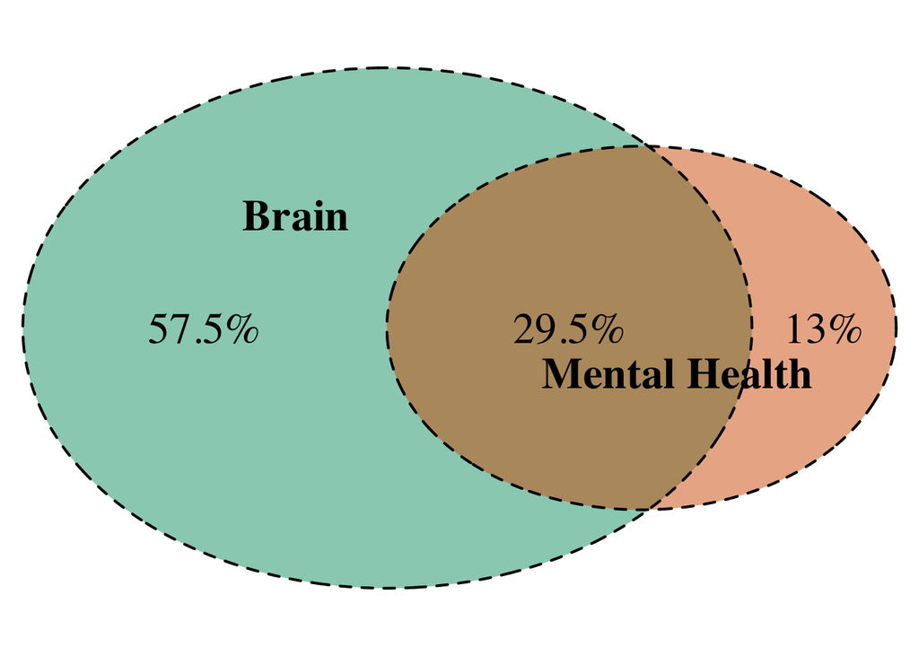

```r
venn_plot_baseline_no_gene_percent <- draw.pairwise.venn(area1 =baseline_no_gene_vec_corrected_percent[1]+baseline_no_gene_vec_corrected_percent[3],
  area2 = baseline_no_gene_vec_corrected_percent[2]+baseline_no_gene_vec_corrected_percent[3],
  cross.area  = baseline_no_gene_vec_corrected_percent[3],
  category = c("Brain", "Mental Health"),
  fill = c("#009E73", "#D55E00"),
  lty = "dashed",
  cat.col = c("black", "black"),
  filename = NULL,
  cex = 2, ## label font size
  cat.cex = 2,### caption font size
  lwd = 2,
  cat.fontface = "bold",
  cat.dist = c(-0.1, -0.1), # Modified
  cat.pos = c(-30, 150),# Modified
  print.mode="percent")
```

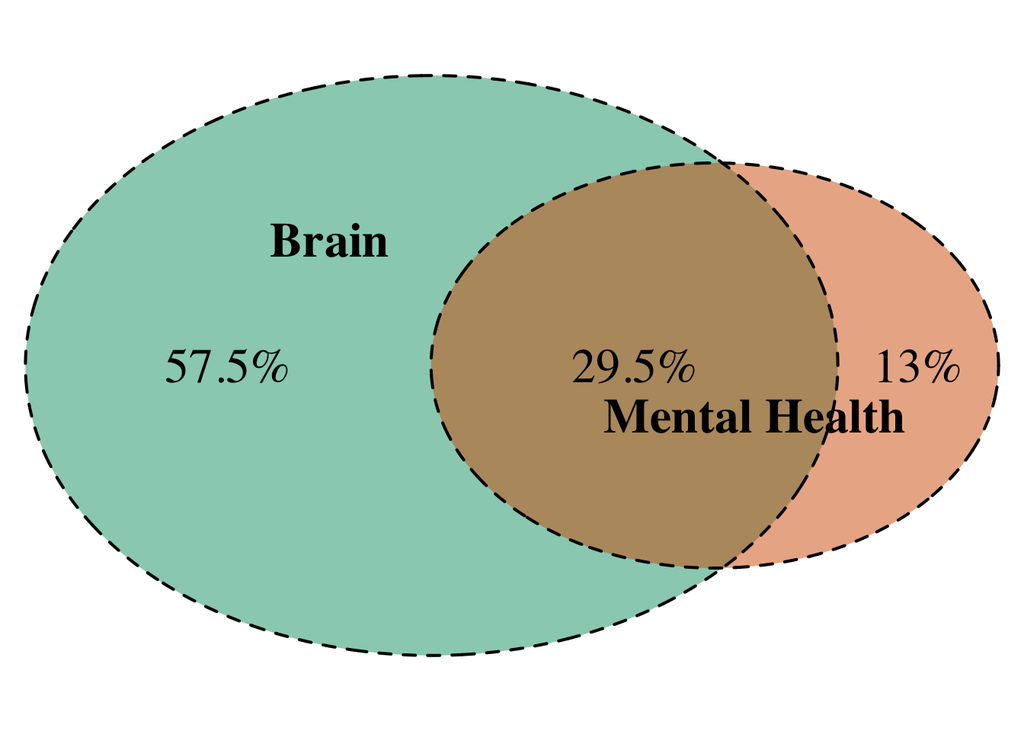

```r
grid.newpage()

grid::grid.draw(venn_plot_baseline_no_gene_percent)
```

```r
#invisible(dev.off())
```

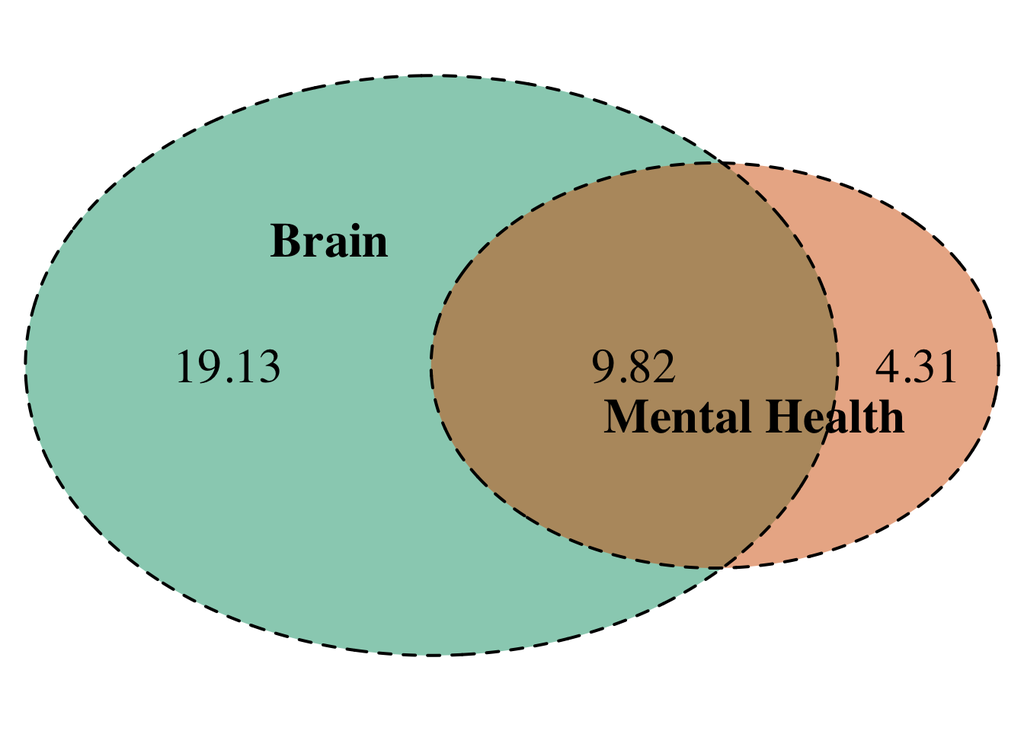

```r
venn_plot_baseline_no_gene_raw <- draw.pairwise.venn(area1 =baseline_no_gene_vec_corrected_raw[1]+baseline_no_gene_vec_corrected_raw[3],
  area2 = baseline_no_gene_vec_corrected_raw[2]+baseline_no_gene_vec_corrected_raw[3],
  cross.area  = baseline_no_gene_vec_corrected_raw[3],
  category = c("Brain", "Mental Health"),
  fill = c("#009E73", "#D55E00"),
  lty = "dashed",
  cat.col = c("black", "black"),
  filename = NULL,
  cex = 2, ## label font size
  cat.cex = 2,### caption font size
  lwd = 2,
  cat.fontface = "bold",
  cat.dist = c(-0.1, -0.1), # Modified
  cat.pos = c(-30, 150),# Modified
  #print.mode="percent"
  )
```

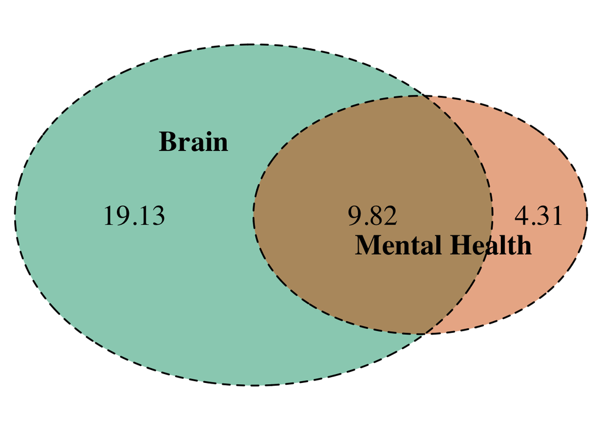

```r
grid.newpage()

grid::grid.draw(venn_plot_baseline_no_gene_raw)
```

```r
#invisible(dev.off())
```

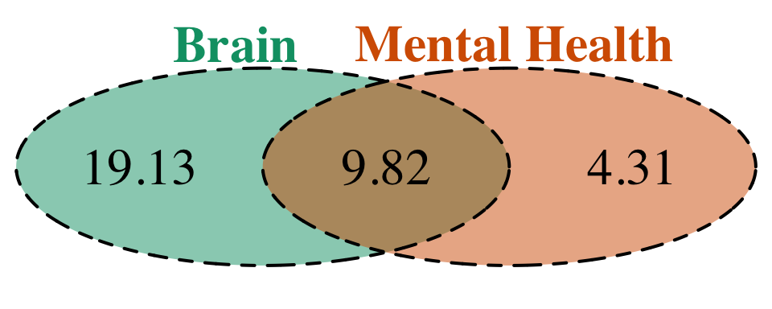

```r
venn_plot_baseline_no_gene_raw <- draw.pairwise.venn(area1 =baseline_no_gene_vec_corrected_raw[1]+baseline_no_gene_vec_corrected_raw[3],
  area2 = baseline_no_gene_vec_corrected_raw[2]+baseline_no_gene_vec_corrected_raw[3],
  cross.area  = baseline_no_gene_vec_corrected_raw[3],
  category = c("Brain", "Mental Health"),
  fill = c("#009E73", "#D55E00"),
  lty = "dashed",
  cat.col = c("#009E73", "#D55E00"),
  filename = NULL,
  cex = 2, ## label font size
  cat.cex = 2,### caption font size
  lwd = 2,
  cat.fontface = "bold",
   cat.dist = c(0.05, 0.05), # Modified
  cat.pos = c(-5, 1),# Modified
  scaled = FALSE
  #print.mode="percent"
  )
```

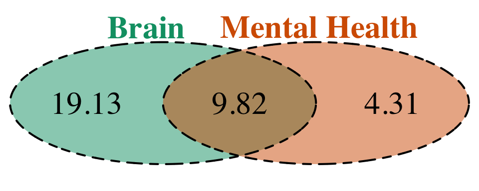

```r
grid.newpage()

grid::grid.draw(venn_plot_baseline_no_gene_raw)
```

```r
#invisible(dev.off())
```

### 2.0.2 venn diagram for followup

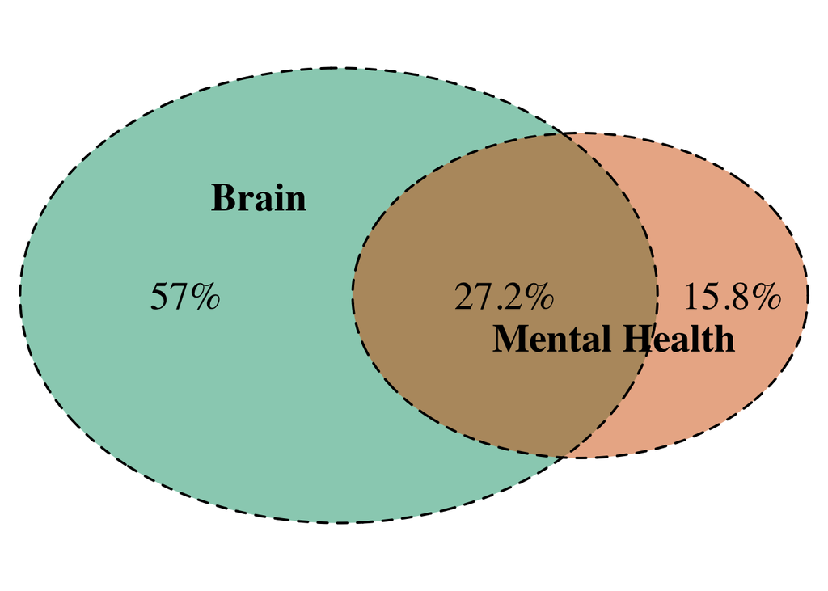

```r
venn_plot_no_gene_followup_percent <- draw.pairwise.venn(area1 =no_brain_vec_corrected_followup_percent[1]+no_brain_vec_corrected_followup_percent[3],
  area2 = no_brain_vec_corrected_followup_percent[2]+no_brain_vec_corrected_followup_percent[3],
  cross.area  = no_brain_vec_corrected_followup_percent[3],
  category = c("Brain", "Mental Health"),
  fill = c("#009E73", "#D55E00"),
  lty = "dashed",
  cat.col = c("black", "black"),
  filename = NULL,
  cex = 2, ## label font size
  cat.cex = 2,### caption font size
  lwd = 2,
  cat.fontface = "bold",
  cat.dist = c(-0.1, -0.1), # Modified
  cat.pos = c(-30, 150),# Modified
  print.mode="percent"
  )
```

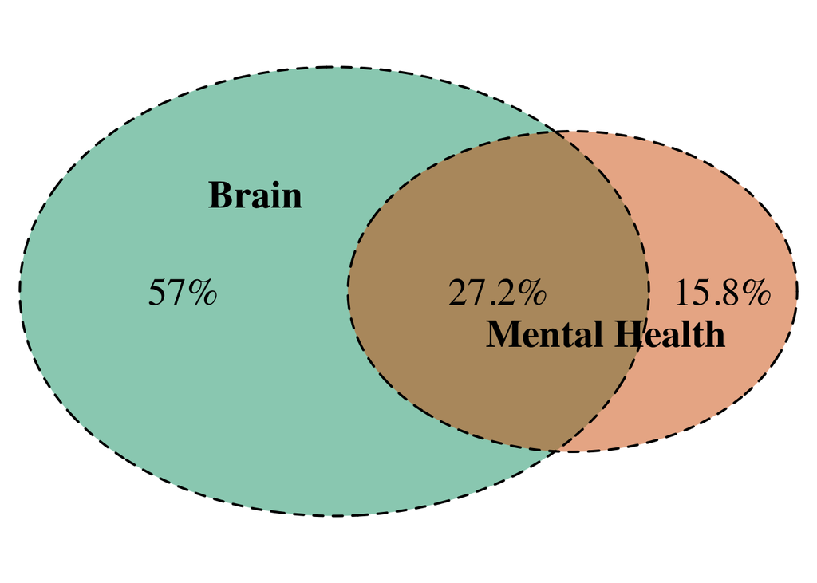

```r
grid.newpage()

grid::grid.draw(venn_plot_no_gene_followup_percent)
```

```r
#invisible(dev.off())
```

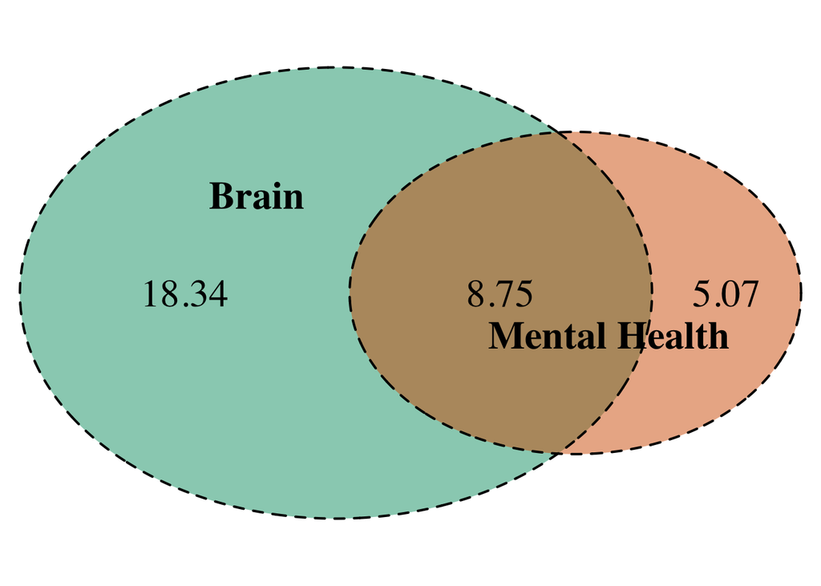

```r
venn_plot_no_gene_followup_raw <- draw.pairwise.venn(area1 =no_brain_vec_corrected_followup_raw[1]+no_brain_vec_corrected_followup_raw[3],
  area2 = no_brain_vec_corrected_followup_raw[2]+no_brain_vec_corrected_followup_raw[3],
  cross.area  = no_brain_vec_corrected_followup_raw[3],
  category = c("Brain", "Mental Health"),
  fill = c("#009E73", "#D55E00"),
  lty = "dashed",
  cat.col = c("black", "black"),
  filename = NULL,
  cex = 2, ## label font size
  cat.cex = 2,### caption font size
  lwd = 2,
  cat.fontface = "bold",
  cat.dist = c(-0.1, -0.1), # Modified
  cat.pos = c(-30, 150),# Modified
  #print.mode="percent"
  )
```

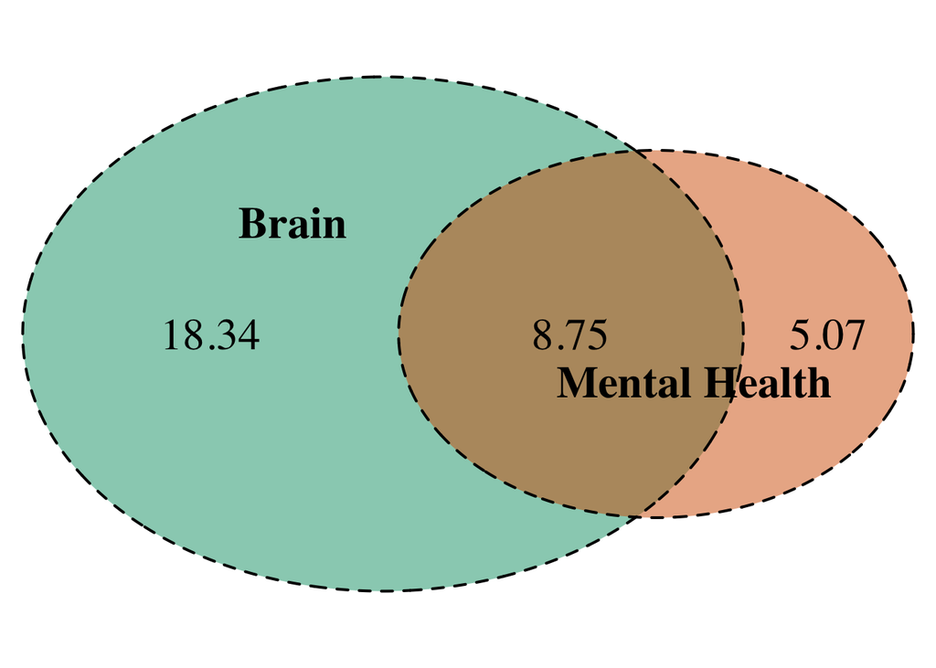

```r
grid.newpage()

grid::grid.draw(venn_plot_no_gene_followup_raw)
```

```r
#invisible(dev.off())
```

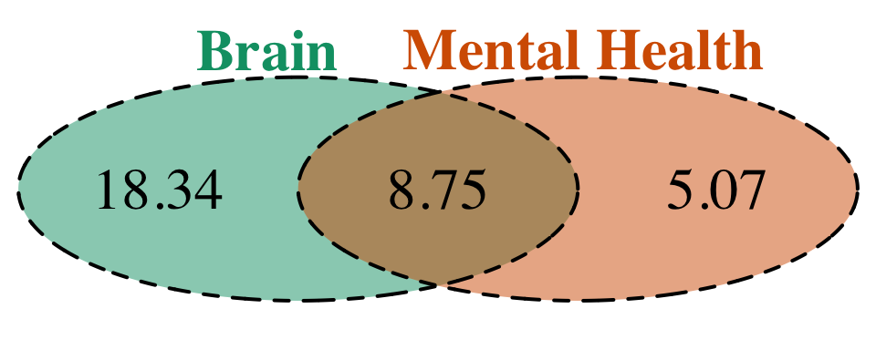

```r
venn_plot_no_gene_followup_raw <- draw.pairwise.venn(area1 =no_brain_vec_corrected_followup_raw[1]+no_brain_vec_corrected_followup_raw[3],
  area2 = no_brain_vec_corrected_followup_raw[2]+no_brain_vec_corrected_followup_raw[3],
  cross.area  = no_brain_vec_corrected_followup_raw[3],
  category = c("Brain", "Mental Health"),
  fill = c("#009E73", "#D55E00"),
  lty = "dashed",
  cat.col = c("#009E73", "#D55E00"),
  filename = NULL,
  cex = 2, ## label font size
  cat.cex = 2,### caption font size
  lwd = 2,
  cat.fontface = "bold",
  cat.dist = c(0.05, 0.05), # Modified
  cat.pos = c(-5, 1),# Modified
  scaled = FALSE
  #print.mode="percent"
  )
```

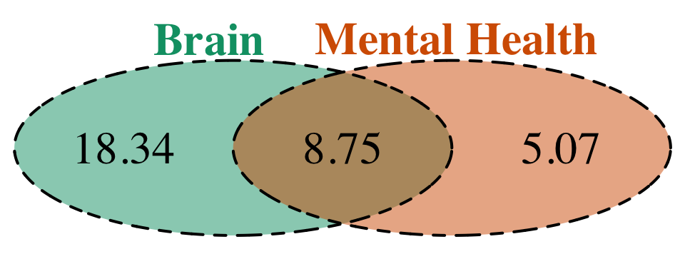

```r
grid.newpage()

grid::grid.draw(venn_plot_no_gene_followup_raw)
```

```r
#invisible(dev.off())
```